# Linear, Generalized Linear, and Mixed/Multilevel models - an introduction with R

December 2014 - January 2015

## Modern statistics are easier than this

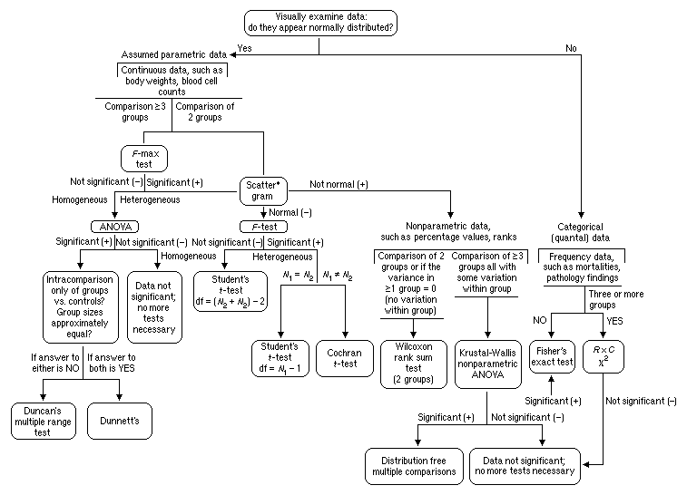

## Our overarching regression framework

\[ \begin{aligned} y_{i}=a+bx_{i}+\varepsilon _{i} \\ \varepsilon _{i}\sim N\left( 0,\sigma^2 \right) \\ \end{aligned} \]

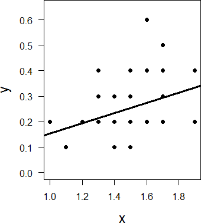

**Data**

**y** = response variable  
**x** = predictor

**Parameters**

*a* = intercept  
*b* = slope  
\(\sigma\) = residual variation

\(\varepsilon\) = residuals

## Residual variation (error)

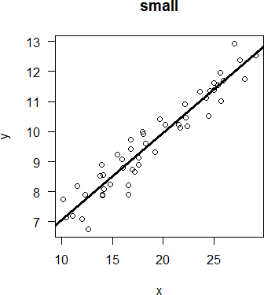

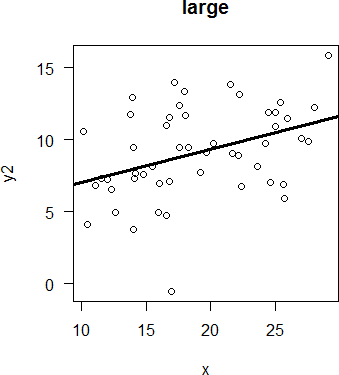

## Residual variation

\[ \begin{aligned} \varepsilon _{i}\sim N\left( 0,\sigma^2 \right) \\ \end{aligned} \]

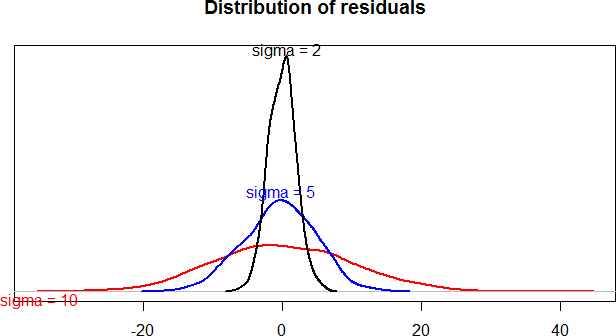

## Quick refresher of linear models

Go to http://vincentarelbundock.github.io/Rdatasets/datasets.html and download `iris` dataset.

Q: What is the relationship between petal width and length in *Iris setosa*?

## Always plot your data first!

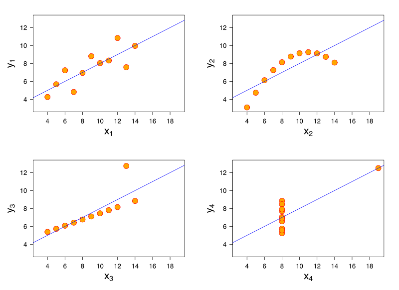

## Exploratory Data Analysis (EDA)

Outliers

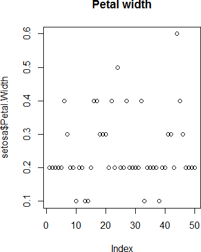

```r
plot(setosa$Petal.Width, main = "Petal width")
```

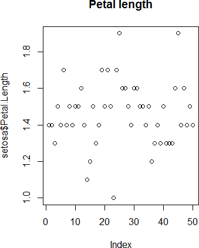

```r
plot(setosa$Petal.Length, main = "Petal length")
```

## Outliers impact on regression

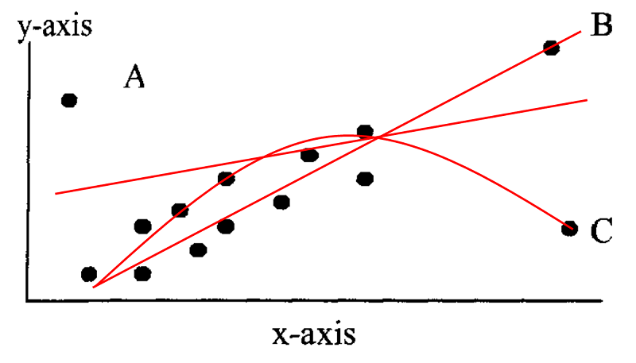

## Histogram

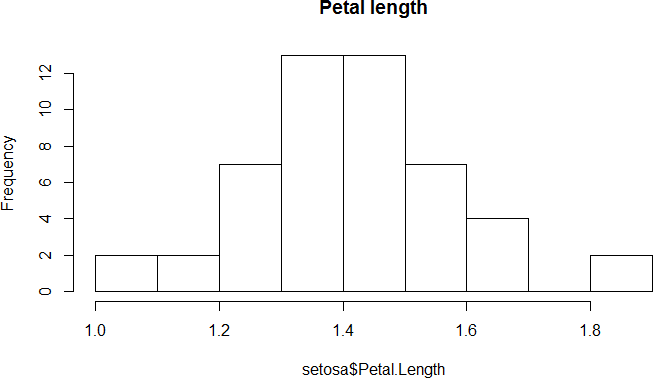

```r
hist(setosa$Petal.Length, main = "Petal length")
```

## Scatterplot

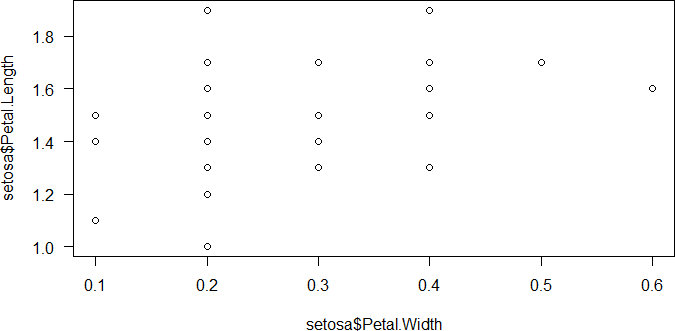

```r
plot(setosa$Petal.Width, setosa$Petal.Length, las = 1)
```

## Now fit model

Hint: `lm`

```r
m1 <- lm(Petal.Length ~ Petal.Width, data = setosa)
```

## What does this mean?

```
Call:
lm(formula = Petal.Length ~ Petal.Width, data = setosa)

Residuals:
     Min       1Q   Median       3Q      Max
-0.43686 -0.09151 -0.03686  0.09018  0.46314

Coefficients:
            Estimate Std. Error t value Pr(>|t|)
(Intercept)  1.32756    0.05996  22.141   <2e-16 ***
Petal.Width  0.54649    0.22439   2.435   0.0186 *
---
Signif. codes:  0 '***' 0.001 '**' 0.01 '*' 0.05 '.' 0.1 ' ' 1

Residual standard error: 0.1655 on 48 degrees of freedom
Multiple R-squared:   0.11, Adjusted R-squared:  0.09144
F-statistic: 5.931 on 1 and 48 DF,  p-value: 0.01864
```

## Plot model

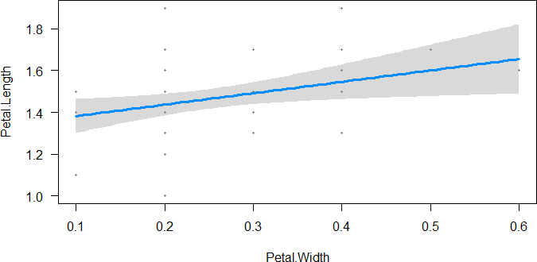

```r
library(visreg)
visreg(m1)
```

## Linear model assumptions

- Linearity (transformations, GAM…)
- Residuals:
  - Independent
  - Equal variance
  - Normal
- No measurement error in predictors

## Model checking: residuals

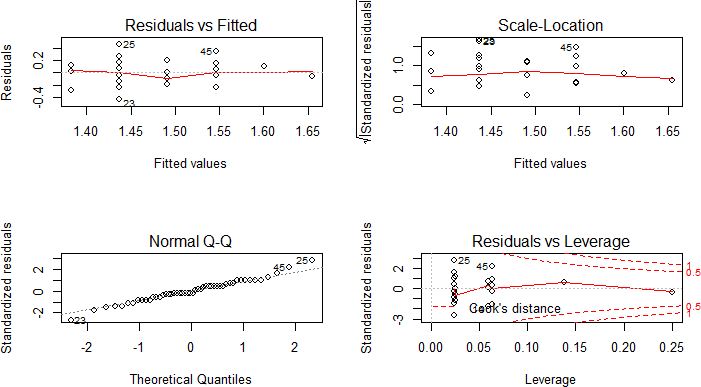

## Are residuals normal?

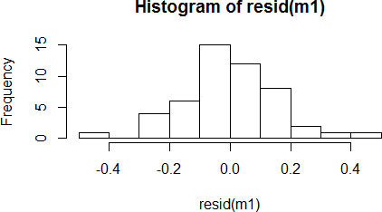

SD of residuals = 0.16 coincides with estimate of `sigma`:

```
lm(formula = Petal.Length ~ Petal.Width, data = setosa)
            coef.est coef.se
(Intercept) 1.33     0.06
Petal.Width 0.55     0.22
---
n = 50, k = 2
residual sd = 0.17, R-Squared = 0.11
```

## How good is the model in predicting petal length?

### Observed vs Predicted values

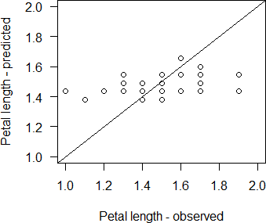

```r
plot(setosa$Petal.Length, fitted(m1), las = 1, xlim = c(1, 2), ylim = c(1, 2),
    xlab = "Petal length - observed", ylab = "Petal length - predicted")
```

Concordant with low R-squared!

## Categorical predictors (factors)

## Q: Does petal length vary among *Iris* species?

\[ y_{i}=a+bx_{i}+\varepsilon _{i} \\ y_{i}=a+b_{versicolor}+c_{virginica}+\varepsilon _{i} \]

## EDA

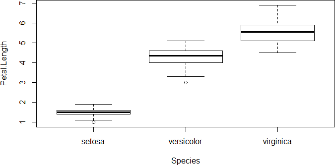

```r
plot(Petal.Length ~ Species, data = iris)
```

## Model

```r
m2 <- lm(Petal.Length ~ Species, data = iris)
```

```
Call:
lm(formula = Petal.Length ~ Species, data = iris)

Residuals:
   Min     1Q Median     3Q    Max
-1.260 -0.258  0.038  0.240  1.348

Coefficients:
                  Estimate Std. Error t value Pr(>|t|)
(Intercept)        1.46200    0.06086   24.02   <2e-16 ***
Speciesversicolor  2.79800    0.08607   32.51   <2e-16 ***
Speciesvirginica   4.09000    0.08607   47.52   <2e-16 ***
---
Signif. codes:  0 '***' 0.001 '**' 0.01 '*' 0.05 '.' 0.1 ' ' 1

Residual standard error: 0.4303 on 147 degrees of freedom
Multiple R-squared:  0.9414,    Adjusted R-squared:  0.9406
F-statistic:  1180 on 2 and 147 DF,  p-value: < 2.2e-16
```

## Alternatively, no intercept

```r
m3 <- lm(Petal.Length ~ Species - 1, data = iris)
```

```
Call:
lm(formula = Petal.Length ~ Species - 1, data = iris)

Residuals:
   Min     1Q Median     3Q    Max
-1.260 -0.258  0.038  0.240  1.348

Coefficients:
                  Estimate Std. Error t value Pr(>|t|)
Speciessetosa      1.46200    0.06086   24.02   <2e-16 ***
Speciesversicolor  4.26000    0.06086   70.00   <2e-16 ***
Speciesvirginica   5.55200    0.06086   91.23   <2e-16 ***
---
Signif. codes:  0 '***' 0.001 '**' 0.01 '*' 0.05 '.' 0.1 ' ' 1

Residual standard error: 0.4303 on 147 degrees of freedom
Multiple R-squared:  0.9895,    Adjusted R-squared:  0.9892
F-statistic:  4600 on 3 and 147 DF,  p-value: < 2.2e-16
```

## Petal length differences across 3 *Iris* species

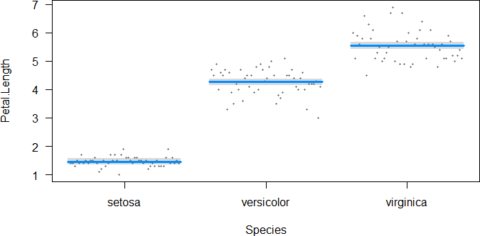

```r
visreg(m3)
```

## Generalised Linear Models (GLMs)

## Q: Survival of passengers on the Titanic ~ Class

```r
titanic <- read.csv("data-raw/titanic_long.csv")
```

```
  class   age  sex survived
1 first adult male        1
2 first adult male        1
3 first adult male        1
4 first adult male        1
5 first adult male        1
6 first adult male        1
```

## Let's fit linear model:

```r
m5 <- lm(survived ~ class, data = titanic)
```

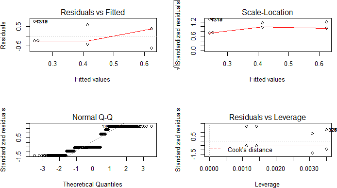

## Weird residuals!

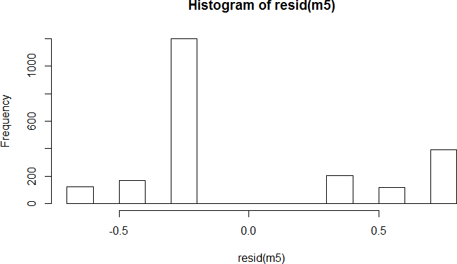

## What if your residuals are clearly non-normal? And variance not constant (heteroscedasticity)?

- Binary variables (0/1)
- Counts (0, 1, 2, 3, …)

## Generalised Linear Models

1. **Response variable** - distribution `family`
   - Bernouilli - Binomial
   - Poisson
   - Gamma
   - etc
2. **Predictors** (continuous or categorical)
3. **Link function**
   - Gaussian: identity
   - Binomial: logit, probit
   - Poisson: log…
   - See [`family`](http://www.rdocumentation.org/packages/stats/functions/family).

## Bernouilli - Binomial distribution (Logistic regression)

- Response variable: Yes/No (e.g. survival, sex, presence/absence)
- Link function: `logit` (others possible, see `family`).

\[ logit(p) = \ln \left( \dfrac {p} {1-p}\right) \]

Then

\[ Pr(alive) = a + bx \\ logit(Pr(alive)) = a + bx \\ Pr(alive) = invlogit(a + bx) = \dfrac {e^{a+bx}} {1+e^{a+bx}} \]

## Back to survival of Titanic passengers

How many passengers travelled in each class?

```r
tapply(titanic$survived, titanic$class, length)  # or aggregate, by...
```

```
  crew  first second  third
   885    325    285    706
```

How many survived?

```r
tapply(titanic$survived, titanic$class, sum)
```

```
  crew  first second  third
   212    203    118    178
```

What proportion survived in each class?

```
[1] 0.2395480 0.6246154 0.4140351 0.2521246
```

## Back to survival of Titanic passengers (dplyr)

Passenger survival according to class

```r
library(dplyr)
titanic %>% group_by(class, survived) %>% summarise(count = n())
```

```
Source: local data frame [8 x 3]
Groups: class

   class survived count
1   crew        0   673
2   crew        1   212
3  first        0   122
4  first        1   203
5 second        0   167
6 second        1   118
7  third        0   528
8  third        1   178
```

Or `summarise(group_by(titanic, class, survived), count = n())`

## Or graphically…

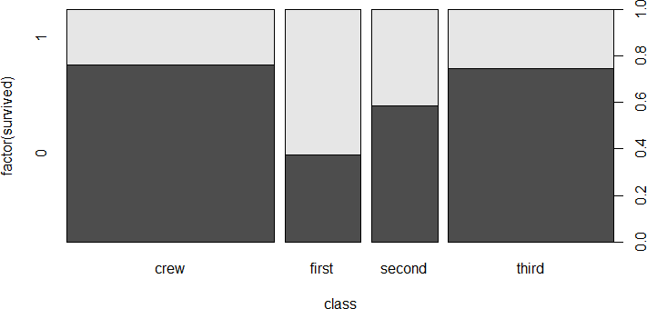

```r
plot(factor(survived) ~ class, data = titanic)
```

## Fitting GLMs in R: `glm`

```r
tit.glm <- glm(survived ~ class, data = titanic, family = binomial)
```

```
Call:
glm(formula = survived ~ class, family = binomial, data = titanic)

Deviance Residuals:
    Min       1Q   Median       3Q      Max
-1.3999  -0.7623  -0.7401   0.9702   1.6906

Coefficients:
            Estimate Std. Error z value Pr(>|z|)
(Intercept) -1.15516    0.07876 -14.667  < 2e-16 ***
classfirst   1.66434    0.13902  11.972  < 2e-16 ***
classsecond  0.80785    0.14375   5.620 1.91e-08 ***
classthird   0.06785    0.11711   0.579    0.562
---
Signif. codes:  0 '***' 0.001 '**' 0.01 '*' 0.05 '.' 0.1 ' ' 1

(Dispersion parameter for binomial family taken to be 1)

    Null deviance: 2769.5  on 2200  degrees of freedom
Residual deviance: 2588.6  on 2197  degrees of freedom
AIC: 2596.6

Number of Fisher Scoring iterations: 4
```

These estimates are in logit scale!

## Interpreting logistic regression output

Parameter estimates (logit-scale)

```
(Intercept)  classfirst classsecond  classthird
-1.15515905  1.66434399  0.80784987  0.06784632
```

**We need to back-transform**: apply *inverse logit*  
Crew probability of survival:

```r
plogis(coef(tit.glm)[1])
```

```
(Intercept)
   0.239548
```

Looking at the data, the proportion of crew who survived is

```
[1] 0.239548
```

## Q: Probability of survival for 1st class passengers?

```r
plogis(coef(tit.glm)[1] + coef(tit.glm)[2])
```

```
(Intercept)
  0.6246154
```

Needs to add intercept (baseline) to the parameter estimate. Again this value matches the data:

```r
sum(titanic$survived[titanic$class == "first"])/nrow(titanic[titanic$class ==
    "first", ])
```

```
[1] 0.6246154
```

## Model interpretation using `effects` package

```r
library(effects)
allEffects(tit.glm)
```

```
 model: survived ~ class

 class effect
class
     crew     first    second     third
0.2395480 0.6246154 0.4140351 0.2521246
```

## Effects plot

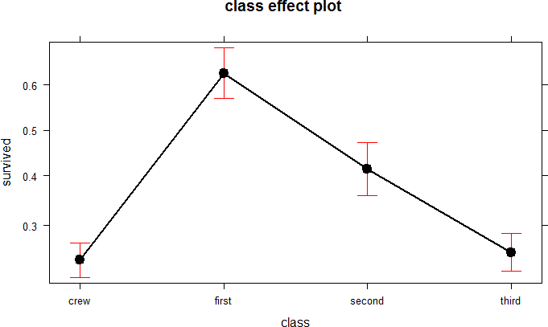

```r
plot(allEffects(tit.glm))
```

## Logistic regression: model checking

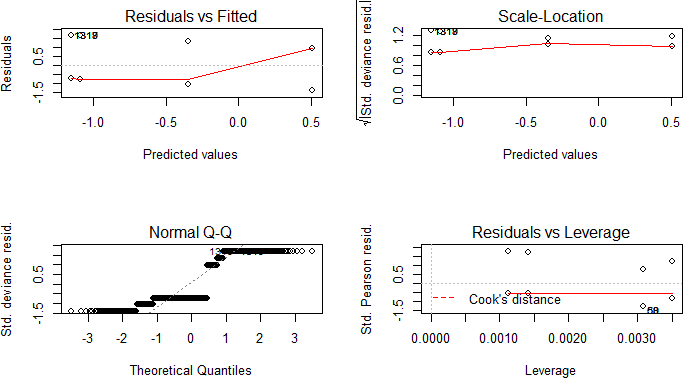

Not very useful.

## Binned residual plots for logistic regression

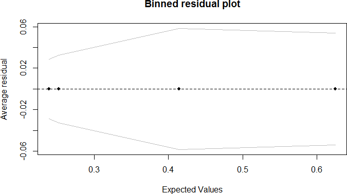

```r
predvals <- predict(tit.glm, type = "response")
arm::binnedplot(predvals, titanic$survived - predvals)
```

## Recapitulating

1. Import data: `read.table` or `read.csv`
2. Check data: `summary`
3. Plot data: `plot`
4. Fit model: `glm`. Don't forget to specify `family`!
5. Examine models: `summary`
6. Use `plogis` to apply back-transformation (*invlogit*) to parameter estimates (`coef`). Alternatively, use `allEffects` from `effects` package.
7. Plot model: `plot(allEffects(model))`. Or use `visreg`.
8. Examine residuals: `binnedplot` from package `arm`. Use `predict` to obtain predicted values for each obs.

## Q: Did men have higher survival than women?

## Plot first

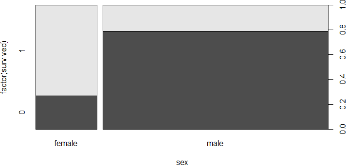

```r
plot(factor(survived) ~ sex, data = titanic)
```

## Fit model

```r
tit.sex <- glm(survived ~ sex, data = titanic, family = binomial)
```

```
Call:
glm(formula = survived ~ sex, family = binomial, data = titanic)

Deviance Residuals:
    Min       1Q   Median       3Q      Max
-1.6226  -0.6903  -0.6903   0.7901   1.7613

Coefficients:
            Estimate Std. Error z value Pr(>|z|)
(Intercept)   1.0044     0.1041   9.645   <2e-16 ***
sexmale      -2.3172     0.1196 -19.376   <2e-16 ***
---
Signif. codes:  0 '***' 0.001 '**' 0.01 '*' 0.05 '.' 0.1 ' ' 1

(Dispersion parameter for binomial family taken to be 1)

    Null deviance: 2769.5  on 2200  degrees of freedom
Residual deviance: 2335.0  on 2199  degrees of freedom
AIC: 2339

Number of Fisher Scoring iterations: 4
```

## Effects

```
 model: survived ~ sex

 sex effect
sex
   female      male
0.7319149 0.2120162
```

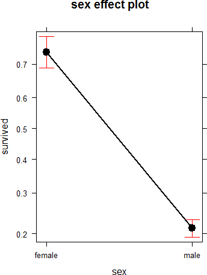

## Q: Did women have higher survival because they travelled more in first class?

## Let's look at the data

`tapply`

```r
tapply(titanic$survived, list(titanic$class, titanic$sex), sum)
```

```
       female male
crew       20  192
first     141   62
second     93   25
third      90   88
```

Mmmm…

## Fit model with both factors (interactions)

```r
tit.sex.class <- glm(survived ~ class * sex, data = titanic, family = binomial)
```

```
glm(formula = survived ~ class * sex, family = binomial, data = titanic)
                    coef.est coef.se
(Intercept)          1.90     0.62
classfirst           1.67     0.80
classsecond          0.07     0.69
classthird          -2.06     0.64
sexmale             -3.15     0.62
classfirst:sexmale  -1.06     0.82
classsecond:sexmale -0.64     0.72
classthird:sexmale   1.74     0.65
---
  n = 2201, k = 8
  residual deviance = 2163.7, null deviance = 2769.5 (difference = 605.7)
```

## Effects

```
 model: survived ~ class * sex

 class*sex effect
        sex
class       female      male
  crew   0.8695652 0.2227378
  first  0.9724138 0.3444444
  second 0.8773585 0.1396648
  third  0.4591837 0.1725490
```

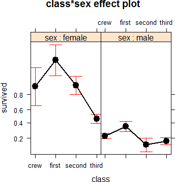

So, women had higher probability of survival than men, even within the same class.

## Logistic regression for proportion data

## Read Titanic data in different format

```r
tit.prop <- read.csv("http://vincentarelbundock.github.io/Rdatasets/csv/datasets/Titanic.csv")
summary(tit.prop)
```

```
       X          Class       Sex        Age     Survived      Freq
 Min.   : 1.00   1st :8   Female:16   Adult:16   No :16   Min.   :  0.00
 1st Qu.: 8.75   2nd :8   Male  :16   Child:16   Yes:16   1st Qu.:  0.75
 Median :16.50   3rd :8                                   Median : 13.50
 Mean   :16.50   Crew:8                                   Mean   : 68.78
 3rd Qu.:24.25                                            3rd Qu.: 77.00
 Max.   :32.00                                            Max.   :670.00
```

These are the same data, but summarized (see `Freq` variable).

## Reshaping data frame

```r
library(reshape2)
tit.prop <- dcast(tit.prop, Class + Sex + Age ~ Survived)
```

## Load dataset

```r
tit.prop <- read.csv("data-raw/Titanic_prop.csv")
```

## Use cbind(n.success, n.failures) as response

```r
prop.glm <- glm(cbind(Yes, No) ~ Class, data = tit.prop, family = binomial)
```

```
Call:
glm(formula = cbind(Yes, No) ~ Class, family = binomial, data = tit.prop)

Deviance Residuals:
    Min       1Q   Median       3Q      Max
-9.6404  -0.2915   1.5698   5.0366  10.1516

Coefficients:
            Estimate Std. Error z value Pr(>|z|)
(Intercept)   0.5092     0.1146   4.445 8.79e-06 ***
Class2nd     -0.8565     0.1661  -5.157 2.51e-07 ***
Class3rd     -1.5965     0.1436 -11.114  < 2e-16 ***
ClassCrew    -1.6643     0.1390 -11.972  < 2e-16 ***
---
Signif. codes:  0 '***' 0.001 '**' 0.01 '*' 0.05 '.' 0.1 ' ' 1

(Dispersion parameter for binomial family taken to be 1)

    Null deviance: 671.96  on 13  degrees of freedom
Residual deviance: 491.06  on 10  degrees of freedom
AIC: 545.68

Number of Fisher Scoring iterations: 4
```

## Effects

```
 model: cbind(Yes, No) ~ Class

 Class effect
Class
      1st       2nd       3rd      Crew
0.6246154 0.4140351 0.2521246 0.2395480
```

Compare with former model based on raw data:

```
 model: survived ~ class

 class effect
class
     crew     first    second     third
0.2395480 0.6246154 0.4140351 0.2521246
```

Same results!

## Logistic regression with continuous predictors

Example dataset: [GDP and infant mortality](http://vincentarelbundock.github.io/Rdatasets/doc/car/UN.html)

```r
gdp <- read.csv("http://vincentarelbundock.github.io/Rdatasets/csv/car/UN.csv")
names(gdp) <- c("country", "mortality", "gdp")
summary(gdp)
```

```
           country      mortality           gdp
 Afghanistan   :  1   Min.   :  2.00   Min.   :   36
 Albania       :  1   1st Qu.: 12.00   1st Qu.:  442
 Algeria       :  1   Median : 30.00   Median : 1779
 American.Samoa:  1   Mean   : 43.48   Mean   : 6262
 Andorra       :  1   3rd Qu.: 66.00   3rd Qu.: 7272
 Angola        :  1   Max.   :169.00   Max.   :42416
 (Other)       :201   NA's   :6        NA's   :10
```

## EDA

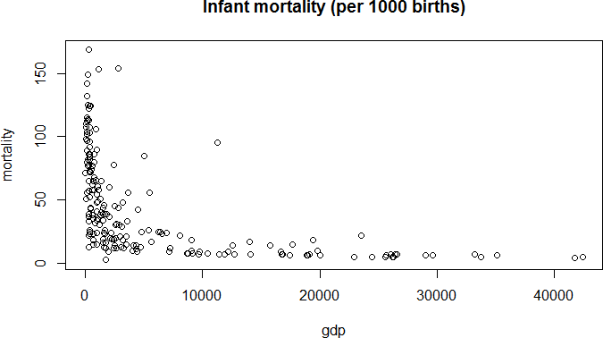

```r
plot(mortality ~ gdp, data = gdp, main = "Infant mortality (per 1000 births)")
```

## Fit model

```r
gdp.glm <- glm(cbind(mortality, 1000 - mortality) ~ gdp, data = gdp, family = binomial)
```

```
Call:
glm(formula = cbind(mortality, 1000 - mortality) ~ gdp, family = binomial,
    data = gdp)

Deviance Residuals:
    Min       1Q   Median       3Q      Max
-9.2230  -3.5163  -0.5697   2.4284  13.5849

Coefficients:
              Estimate Std. Error z value Pr(>|z|)
(Intercept) -2.657e+00  1.311e-02 -202.76   <2e-16 ***
gdp         -1.279e-04  3.458e-06  -36.98   <2e-16 ***
---
Signif. codes:  0 '***' 0.001 '**' 0.01 '*' 0.05 '.' 0.1 ' ' 1

(Dispersion parameter for binomial family taken to be 1)

    Null deviance: 6430.2  on 192  degrees of freedom
Residual deviance: 3530.2  on 191  degrees of freedom
  (14 observations deleted due to missingness)
AIC: 4525.8

Number of Fisher Scoring iterations: 5
```

## Effects

```r
allEffects(gdp.glm)
```

```
 model: cbind(mortality, 1000 - mortality) ~ gdp

 gdp effect
gdp
       10000        20000        30000        40000
0.0191438829 0.0054028095 0.0015096074 0.0004206154
```

## Effects plot

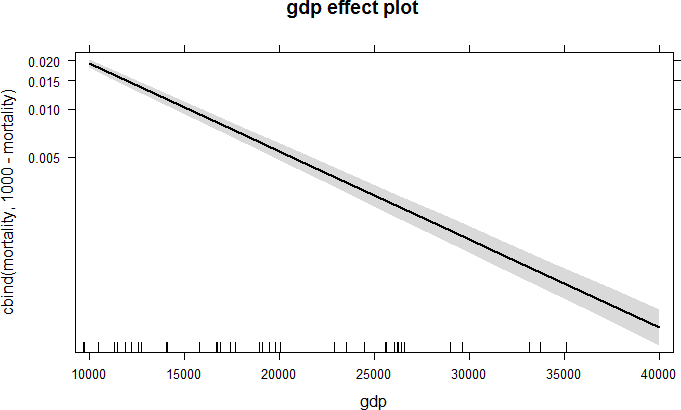

```r
plot(allEffects(gdp.glm))
```

## Plot model and data

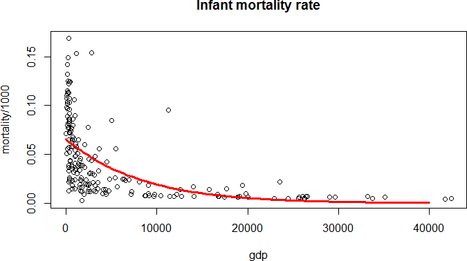

```r
plot(mortality/1000 ~ gdp, data = gdp, main = "Infant mortality rate")
curve(plogis(coef(gdp.glm)[1] + coef(gdp.glm)[2] * x), from = 0, to = 40000,
    add = TRUE, lwd = 3, col = "red")
```

## Or using visreg:

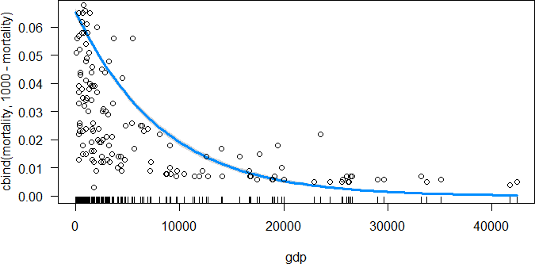

```r
visreg(gdp.glm, scale = "response")
points(mortality/1000 ~ gdp, data = gdp)
```

## Overdispersion

## Overdispersion in logistic regression with proportion data

```r
gdp.overdisp <- glm(cbind(mortality, 1000 - mortality) ~ gdp, data = gdp, family = quasibinomial)
```

```
Call:
glm(formula = cbind(mortality, 1000 - mortality) ~ gdp, family = quasibinomial,
    data = gdp)

Deviance Residuals:
    Min       1Q   Median       3Q      Max
-9.2230  -3.5163  -0.5697   2.4284  13.5849

Coefficients:
              Estimate Std. Error t value Pr(>|t|)
(Intercept) -2.657e+00  5.977e-02 -44.465  < 2e-16 ***
gdp         -1.279e-04  1.577e-05  -8.111 5.96e-14 ***
---
Signif. codes:  0 '***' 0.001 '**' 0.01 '*' 0.05 '.' 0.1 ' ' 1

(Dispersion parameter for quasibinomial family taken to be 20.7947)

    Null deviance: 6430.2  on 192  degrees of freedom
Residual deviance: 3530.2  on 191  degrees of freedom
  (14 observations deleted due to missingness)
AIC: NA

Number of Fisher Scoring iterations: 5
```

## Mean estimates do not change after accounting for overdispersion

```
 model: cbind(mortality, 1000 - mortality) ~ gdp

 gdp effect
gdp
       10000        20000        30000        40000
0.0191438829 0.0054028095 0.0015096074 0.0004206154
```

```
 model: cbind(mortality, 1000 - mortality) ~ gdp

 gdp effect
gdp
       10000        20000        30000        40000
0.0191438829 0.0054028095 0.0015096074 0.0004206154
```

## But standard errors (uncertainty) do!

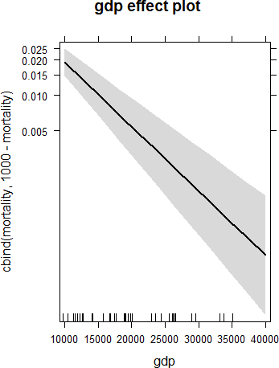

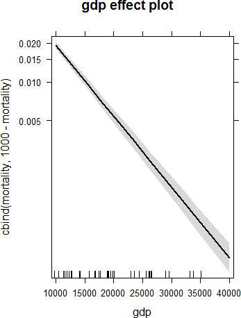

## Plot model and data

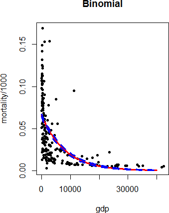

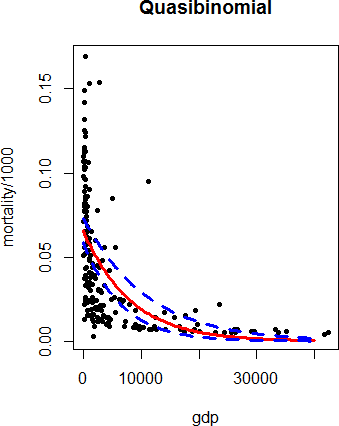

## Overdispersion

Whenever you fit logistic regression to **proportion** data, check family `quasibinomial`.

## GLMs for count data: Poisson regression

## Types of response variable

- Gaussian: `lm`
- Bernouilli / Binomial: `glm` (family `binomial / quasibinomial`)
- Counts: `glm` (family `poisson / quasipoisson`)

## Poisson regression

- Response variable: Counts (0, 1, 2, 3…) - discrete
- Link function: `log`

Then

\[ log(N) = a + bx \\ N = e^{a+bx} \]

## Example dataset: Seedling counts in 0.5 m2 quadrats

```r
seedl <- read.csv("data-raw/seedlings.csv")
```

```
       X             count           row         col
 Min.   : 1.00   Min.   :0.00   Min.   :1   Min.   : 1.0
 1st Qu.:13.25   1st Qu.:1.00   1st Qu.:2   1st Qu.: 3.0
 Median :25.50   Median :2.00   Median :3   Median : 5.5
 Mean   :25.50   Mean   :2.14   Mean   :3   Mean   : 5.5
 3rd Qu.:37.75   3rd Qu.:3.00   3rd Qu.:4   3rd Qu.: 8.0
 Max.   :50.00   Max.   :7.00   Max.   :5   Max.   :10.0
     light
 Min.   : 2.571
 1st Qu.:26.879
 Median :47.493
 Mean   :47.959
 3rd Qu.:67.522
 Max.   :99.135
```

## EDA

```r
table(seedl$count)
```

```
 0  1  2  3  4  5  7
 7 12 13  8  7  2  1
```

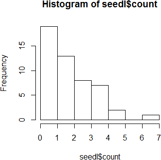

```r
hist(seedl$count)
```

## Q: Relationship between Nseedlings and light?

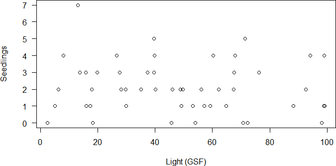

```r
plot(seedl$light, seedl$count, las = 1, xlab = "Light (GSF)", ylab = "Seedlings")
```

## Let's fit model (Poisson regression)

```r
seedl.glm <- glm(count ~ light, data = seedl, family = poisson)
summary(seedl.glm)
```

```
Call:
glm(formula = count ~ light, family = poisson, data = seedl)

Deviance Residuals:
    Min       1Q   Median       3Q      Max
-2.1906  -0.8466  -0.1110   0.5220   2.4577

Coefficients:
             Estimate Std. Error z value Pr(>|z|)
(Intercept)  0.881805   0.188892   4.668 3.04e-06 ***
light       -0.002576   0.003528  -0.730    0.465
---
Signif. codes:  0 '***' 0.001 '**' 0.01 '*' 0.05 '.' 0.1 ' ' 1

(Dispersion parameter for poisson family taken to be 1)

    Null deviance: 63.029  on 49  degrees of freedom
Residual deviance: 62.492  on 48  degrees of freedom
AIC: 182.03

Number of Fisher Scoring iterations: 5
```

## Interpreting Poisson regression output

Parameter estimates (log scale):

```r
coef(seedl.glm)
```

```
 (Intercept)        light
 0.881805022 -0.002575656
```

**We need to back-transform**: apply the inverse of the logarithm

```r
exp(coef(seedl.glm))
```

```
(Intercept)       light
  2.4152554   0.9974277
```

## So what's the relationship between Nseedlings and light?

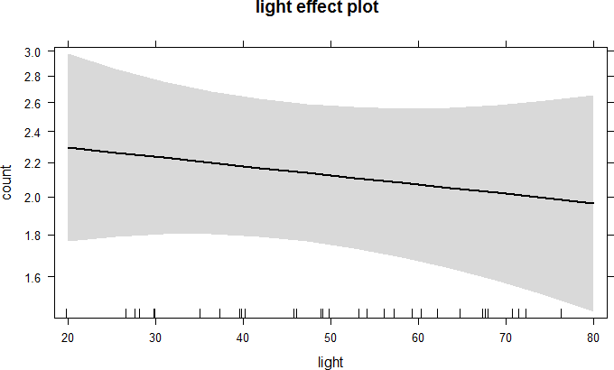

```r
plot(allEffects(seedl.glm))
```

## Using visreg

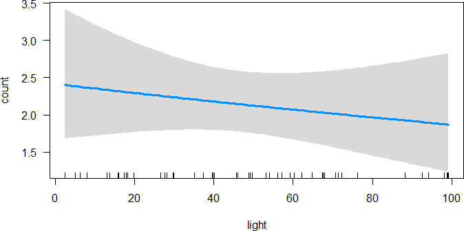

```r
visreg(seedl.glm, scale = "response")
```

## Poisson regression: model checking

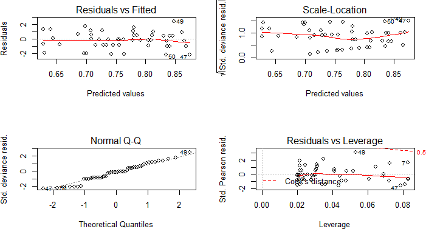

## Is there pattern of residuals along predictor?

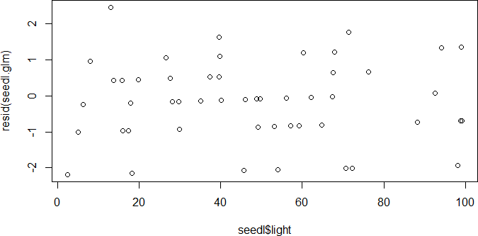

```r
plot(seedl$light, resid(seedl.glm))
```

## Poisson regression: Overdispersion

## Always check overdispersion with count data

Use family `quasipoisson`

```
Call:
glm(formula = count ~ light, family = quasipoisson, data = seedl)

Deviance Residuals:
    Min       1Q   Median       3Q      Max
-2.1906  -0.8466  -0.1110   0.5220   2.4577

Coefficients:
             Estimate Std. Error t value Pr(>|t|)
(Intercept)  0.881805   0.201230   4.382 6.37e-05 ***
light       -0.002576   0.003758  -0.685    0.496
---
Signif. codes:  0 '***' 0.001 '**' 0.01 '*' 0.05 '.' 0.1 ' ' 1

(Dispersion parameter for quasipoisson family taken to be 1.134907)

    Null deviance: 63.029  on 49  degrees of freedom
Residual deviance: 62.492  on 48  degrees of freedom
AIC: NA

Number of Fisher Scoring iterations: 5
```

## Mean estimates do not change after accounting for overdispersion

```
 model: count ~ light

 light effect
light
      20       40       60       80
2.293988 2.178810 2.069414 1.965512
```

```
 model: count ~ light

 light effect
light
      20       40       60       80
2.293988 2.178810 2.069414 1.965512
```

## But standard errors may change

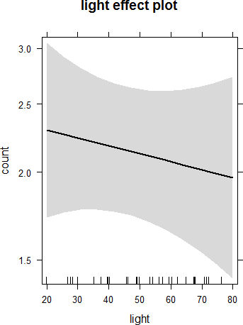

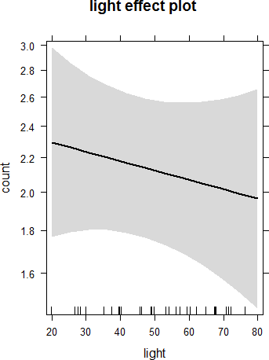

## Mixed / Multilevel Models

## Mixed models enable us to account for variability

- Varying intercepts
- Varying slopes

## Single vs varying intercept

Dataset: 1000 trees from 10 plots (trees per plot: 4 - 392).

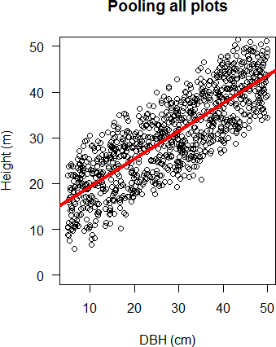

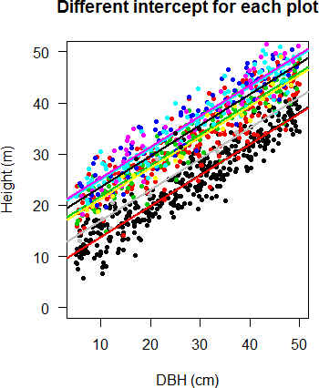

## Fitting a varying intercepts model with `lm`

```
lm(formula = height ~ factor(plot) + dbh, data = trees)
               coef.est coef.se
(Intercept)     7.79     0.24
factor(plot)2   7.86     0.24
factor(plot)3   7.95     0.32
factor(plot)4  11.48     0.33
factor(plot)5  11.05     0.32
factor(plot)6  11.55     0.43
factor(plot)7   7.41     0.63
factor(plot)8   3.05     0.97
factor(plot)9   9.73     1.45
factor(plot)10 -0.14     0.92
dbh             0.61     0.01
---
n = 1000, k = 11
residual sd = 2.89, R-Squared = 0.91
```

[figure not shown]

## Mixed model with varying intercepts

\[ \begin{aligned} y_{i}=a_{j}+bx_{i}+\varepsilon _{i} \\ a_{j} \sim N\left( 0,\tau^2 \right) \\ \varepsilon _{i}\sim N\left( 0,\sigma^2 \right) \\ \end{aligned} \]

En nuestro ejemplo:

\[ \begin{aligned} Height_{i}=plot_{j}+bDBH_{i}+\varepsilon _{i} \\ plot_{j} \sim N\left( 0,\tau^2 \right) \\ \varepsilon _{i}\sim N\left( 0,\sigma^2 \right) \\ \end{aligned} \]

## Fitting mixed/multilevel models

```r
library(lme4)
mixed <- lmer(height ~ dbh + (1 | plot), data = trees)
```

```
Linear mixed model fit by REML ['lmerMod']
Formula: height ~ dbh + (1 | plot)
   Data: trees

REML criterion at convergence: 5007.6

Scaled residuals:
     Min       1Q   Median       3Q      Max
-2.84491 -0.65574 -0.02247  0.69295  3.09733

Random effects:
 Groups   Name        Variance Std.Dev.
 plot     (Intercept) 19.834   4.454
 Residual              8.325   2.885
Number of obs: 1000, groups:  plot, 10

Fixed effects:
            Estimate Std. Error t value
(Intercept) 14.79816    1.43742   10.29
dbh          0.60566    0.00704   86.03

Correlation of Fixed Effects:
    (Intr)
dbh -0.135
```

## Retrieve model coefficients

```r
coef(mixed)
```

```
$plot
   (Intercept)       dbh
1     7.798373 0.6056549
2    15.647613 0.6056549
3    15.735397 0.6056549
4    19.253661 0.6056549
5    18.819467 0.6056549
6    19.306574 0.6056549
7    15.197908 0.6056549
8    11.016485 0.6056549
9    17.265447 0.6056549
10    7.940715 0.6056549

attr(,"class")
[1] "coef.mer"
```

## Visualising model: `allEffects`

```
 model: height ~ dbh

 dbh effect
dbh
      10       20       30       40
20.85471 26.91126 32.96781 39.02436
```

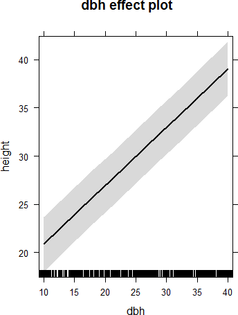

## Visualising model: `visreg`

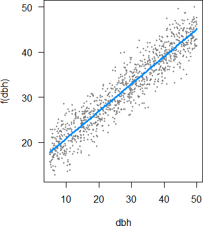

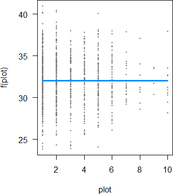

## Plotting regression for individual forest plots

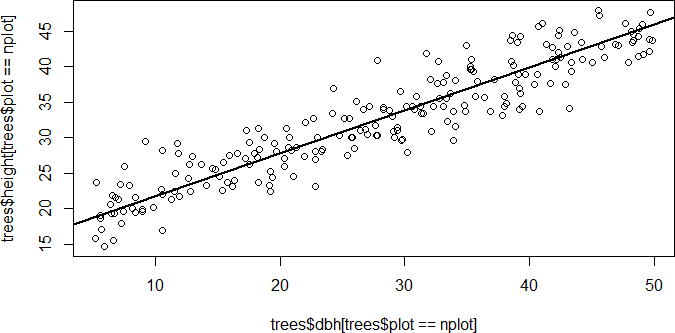

```r
nplot <- 2
plot(trees$dbh[trees$plot == nplot], trees$height[trees$plot == nplot])
abline(a = coef(mixed)$plot[nplot, 1], b = coef(mixed)$plot[nplot, 2], lwd = 2)
```

## Checking residuals

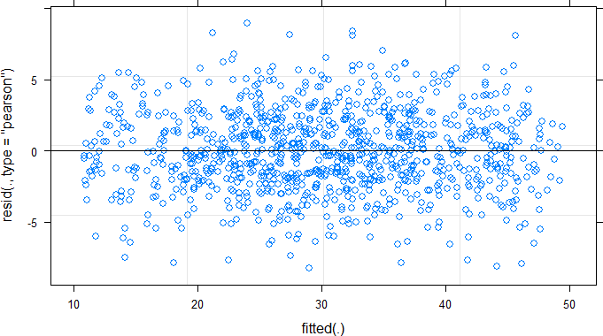

```r
plot(mixed)
```

## Multilevel logistic regression

## Q: Relationship between tree size and mortality

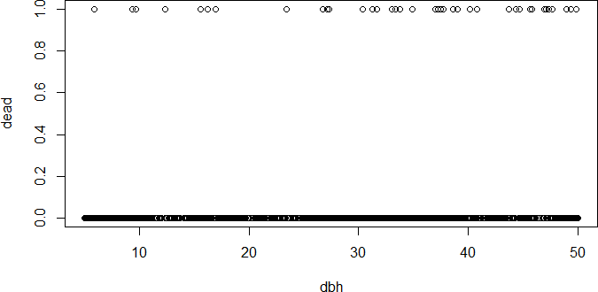

```r
plot(dead ~ dbh, data = trees)
```

## Q: Relationship between tree size and mortality

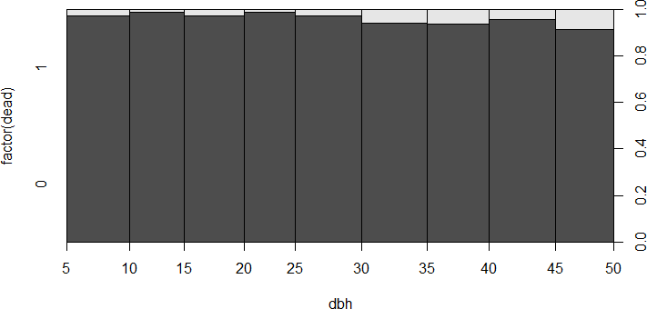

```r
plot(factor(dead) ~ dbh, data = trees)
```

## Fit simple logistic regression

```r
simple.logis <- glm(dead ~ dbh, data = trees, family = binomial)
```

```
Call:
glm(formula = dead ~ dbh, family = binomial, data = trees)

Deviance Residuals:
    Min       1Q   Median       3Q      Max
-0.4121  -0.3287  -0.2624  -0.2048   2.9127

Coefficients:
            Estimate Std. Error z value Pr(>|z|)
(Intercept) -4.46945    0.49445  -9.039  < 2e-16 ***
dbh          0.04094    0.01380   2.967  0.00301 **
---
Signif. codes:  0 '***' 0.001 '**' 0.01 '*' 0.05 '.' 0.1 ' ' 1

(Dispersion parameter for binomial family taken to be 1)

    Null deviance: 329.51  on 999  degrees of freedom
Residual deviance: 319.90  on 998  degrees of freedom
AIC: 323.9

Number of Fisher Scoring iterations: 6
```

## Fit simple logistic regression (with plots)

```r
logis2 <- glm(dead ~ dbh + factor(plot), data = trees, family = binomial)
```

```
Call:
glm(formula = dead ~ dbh + factor(plot), family = binomial, data = trees)

Deviance Residuals:
    Min       1Q   Median       3Q      Max
-0.5923  -0.3198  -0.2549  -0.1940   2.8902

Coefficients:
                 Estimate Std. Error z value Pr(>|z|)
(Intercept)      -4.40106    0.52997  -8.304   <2e-16 ***
dbh               0.04060    0.01386   2.929   0.0034 **
factor(plot)2    -0.59168    0.52132  -1.135   0.2564
factor(plot)3     0.54576    0.47094   1.159   0.2465
factor(plot)4     0.05507    0.57434   0.096   0.9236
factor(plot)5    -0.38312    0.64222  -0.597   0.5508
factor(plot)6    -0.08426    0.76908  -0.110   0.9128
factor(plot)7     0.03126    1.06064   0.029   0.9765
factor(plot)8   -13.09055  788.80571  -0.017   0.9868
factor(plot)9   -13.17298 1197.12463  -0.011   0.9912
factor(plot)10    0.83208    1.09069   0.763   0.4455
---
Signif. codes:  0 '***' 0.001 '**' 0.01 '*' 0.05 '.' 0.1 ' ' 1

(Dispersion parameter for binomial family taken to be 1)

    Null deviance: 329.51  on 999  degrees of freedom
Residual deviance: 314.49  on 989  degrees of freedom
AIC: 336.49

Number of Fisher Scoring iterations: 15
```

## Fit multilevel logistic regression

```r
mixed.logis <- glmer(dead ~ dbh + (1 | plot), data = trees, family = binomial)
```

```
Generalized linear mixed model fit by maximum likelihood (Laplace
  Approximation) [glmerMod]
 Family: binomial  ( logit )
Formula: dead ~ dbh + (1 | plot)
   Data: trees

     AIC      BIC   logLik deviance df.resid
   325.9    340.6   -160.0    319.9      997

Scaled residuals:
    Min      1Q  Median      3Q     Max
-0.2977 -0.2356 -0.1872 -0.1456  8.2792

Random effects:
 Groups Name        Variance Std.Dev.
 plot   (Intercept) 0        0
Number of obs: 1000, groups:  plot, 10

Fixed effects:
            Estimate Std. Error z value Pr(>|z|)
(Intercept) -4.46945    0.49446  -9.039  < 2e-16 ***
dbh          0.04094    0.01380   2.967  0.00301 **
---
Signif. codes:  0 '***' 0.001 '**' 0.01 '*' 0.05 '.' 0.1 ' ' 1

Correlation of Fixed Effects:
    (Intr)
dbh -0.943
```

## Retrieve model coefficients

```r
coef(mixed.logis)
```

```
$plot
   (Intercept)        dbh
1    -4.469446 0.04093806
2    -4.469446 0.04093806
3    -4.469446 0.04093806
4    -4.469446 0.04093806
5    -4.469446 0.04093806
6    -4.469446 0.04093806
7    -4.469446 0.04093806
8    -4.469446 0.04093806
9    -4.469446 0.04093806
10   -4.469446 0.04093806

attr(,"class")
[1] "coef.mer"
```

## Visualising model: `allEffects`

```
 model: dead ~ dbh

 dbh effect
dbh
        10         20         30         40
0.01695545 0.02531581 0.03764063 0.05562328
```

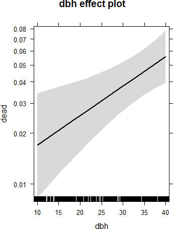

## END

**:)**

Source code and materials: http://github.com/Pakillo/LM-GLM-GLMM-intro